# Week 6 In-class: LaQuinta

Kris Koloini, Matt Hawes, Shyni David, Danielle Lumbatis

## Introduction

LaQuinta is trying to decide where to locate a new motel. As analysts, your team is tasked with determining which factors are relevant in determing profitability and predicting strong locations for expansion. A group of strategists determined factors worthy of exploration are competition, market awareness, demand generators, socio-economic factors, and location.

In preparation, the company has identified and compiled a variety of potential predictors for profitability (measured via operating margin–Margin–of current hotels). They are:

- Number: Total motel and hotel rooms within a 3 mile radius
- Nearest: Number of miles to closest copmetition
- OfficeSpace: Volume of office space in surrounding community, in 1000s sqft
- Enrollment: Number of college and university students in the community, in 1000s
- Income: Median household income, $1000s
- Distance: Distance (in miles) to the downtown core

## Exploratory Analysis

First, load the data and explore some features of interest.

```r
laquinta <- read_csv("https://raw.githubusercontent.com/jddbucknole/SMB-A/master/LaQuinta.csv")
```

Examine the scatterplots relating the explanatory variables to the response (Margin) as well as the correlation. Include a couple plots of interest and the correlation matrix. Comment on what you see. Which variables appear to be impactful in predicting margin? Which influence in a positive manner? Negative manner? Is that what you expected?

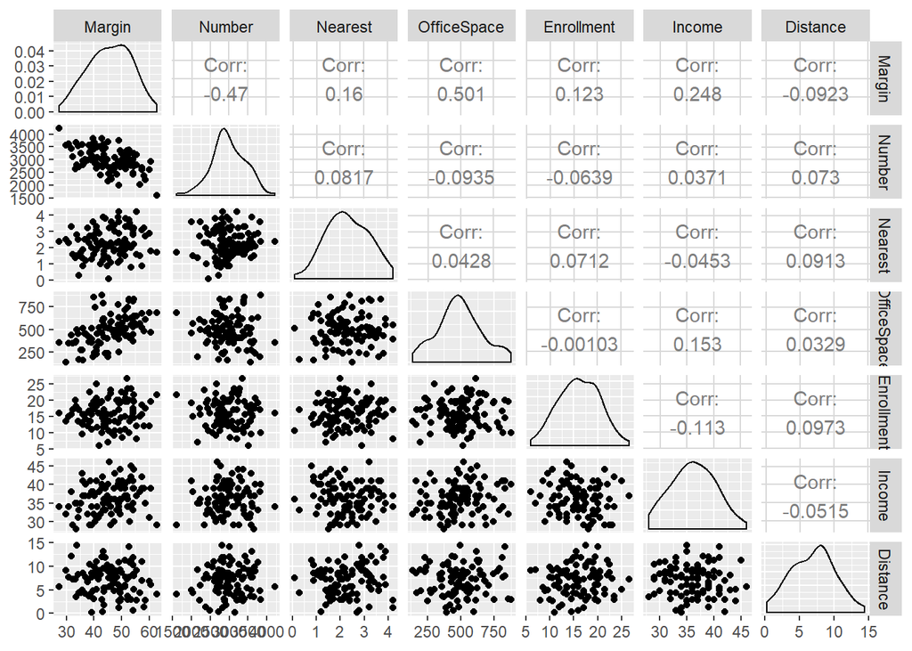

```r
laquinta %>%
  ggpairs()
```

## Simple Linear Regression

Fit a linear model to predict Margin from the single variable that is the **most correlated** with the response. Interpret both coefficients **in context** if they are sensible. If not, explain why not.

```r
laQuintaModel <- lm(Margin ~ OfficeSpace, data = laquinta)

summary(laQuintaModel)
```

```
##
## Call:
## lm(formula = Margin ~ OfficeSpace, data = laquinta)
##
## Residuals:
##      Min       1Q   Median       3Q      Max
## -15.2892  -4.6961   0.3761   4.7261  15.3061
##
## Coefficients:
##             Estimate Std. Error t value Pr(>|t|)
## (Intercept) 34.18846    2.12310  16.103  < 2e-16 ***
## OfficeSpace  0.02347    0.00409   5.737 1.07e-07 ***
## ---
## Signif. codes:  0 '***' 0.001 '**' 0.01 '*' 0.05 '.' 0.1 ' ' 1
##
## Residual standard error: 6.741 on 98 degrees of freedom
##   (1 observation deleted due to missingness)
## Multiple R-squared:  0.2514, Adjusted R-squared:  0.2438
## F-statistic: 32.92 on 1 and 98 DF,  p-value: 1.072e-07
```

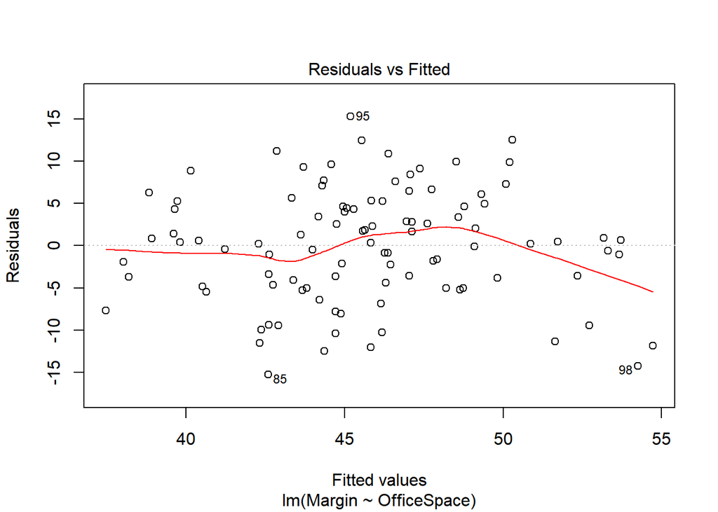

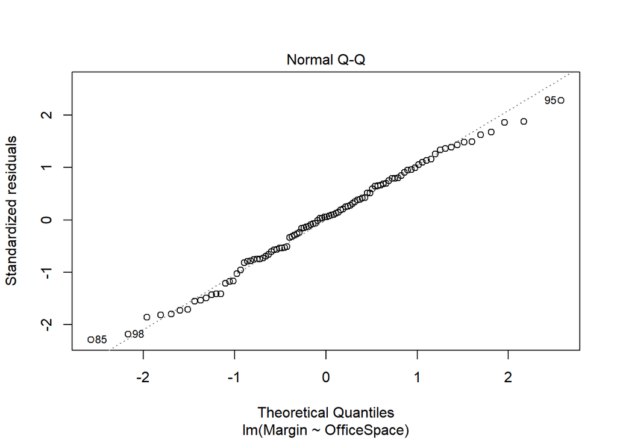

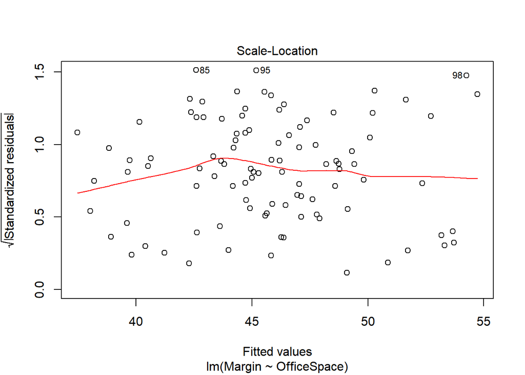

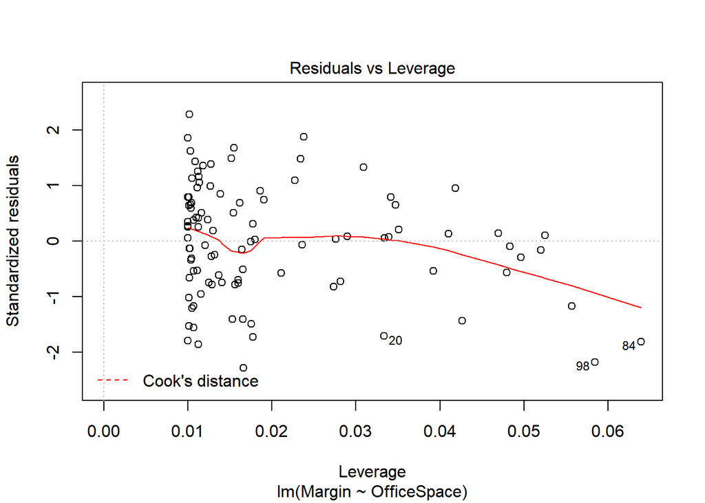

```r
plot(laQuintaModel)
```

```r
'laQuintaModel <- lm(Margin ~ Number, data = laquinta)

summary(laQuintaModel)

plot(laQuintaModel)
'
```

```
## [1] "laQuintaModel <- lm(Margin ~ Number, data = laquinta)\n\nsummary(laQuintaModel)\n\nplot(laQuintaModel)\n"
```

The intercept of the function states that if no office space was present we could expect the Margin to be 34.18. As office space increases by 1000 sqft it increases the Margin by .02.

## Model Fitting

Fit a multiple linear regression model to predict Margin from the other predictors. Produce the “best” model according to whatever criteria you choose. After you have finalized your model, report the summary and any requisite diagnostic plots below (only run the final model in this R markdown file).

```r
laQuintaModelMultiple <- lm(Margin ~ OfficeSpace + Number + Income, data = laquinta)

summary(laQuintaModelMultiple)
```

```
##
## Call:
## lm(formula = Margin ~ OfficeSpace + Number + Income, data = laquinta)
##
## Residuals:
##      Min       1Q   Median       3Q      Max
## -12.8795  -4.4567  -0.2055   4.8474  13.7737
##
## Coefficients:
##              Estimate Std. Error t value Pr(>|t|)
## (Intercept) 44.715172   6.463262   6.918 5.10e-10 ***
## OfficeSpace  0.020137   0.003534   5.698 1.33e-07 ***
## Number      -0.007570   0.001293  -5.857 6.59e-08 ***
## Income       0.378523   0.143796   2.632  0.00988 **
## ---
## Signif. codes:  0 '***' 0.001 '**' 0.01 '*' 0.05 '.' 0.1 ' ' 1
##
## Residual standard error: 5.728 on 96 degrees of freedom
##   (1 observation deleted due to missingness)
## Multiple R-squared:  0.4705, Adjusted R-squared:  0.454
## F-statistic: 28.44 on 3 and 96 DF,  p-value: 3.03e-13
```

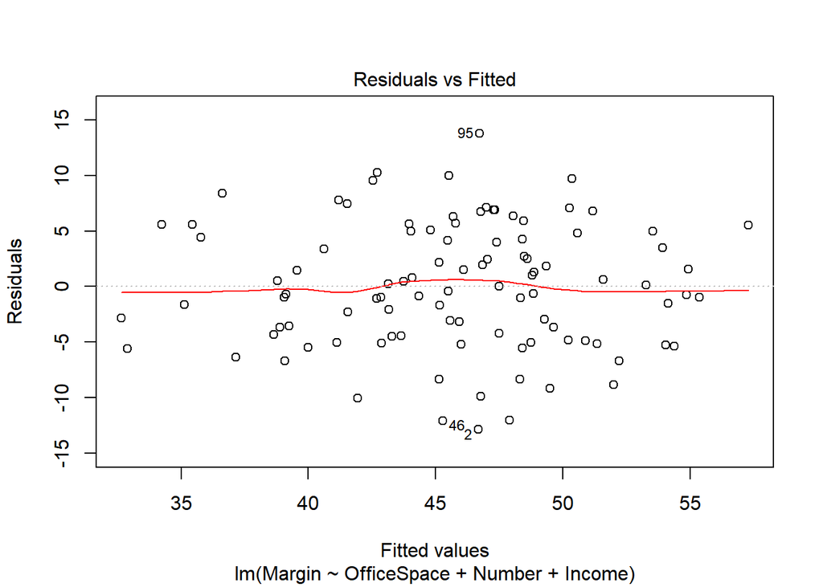

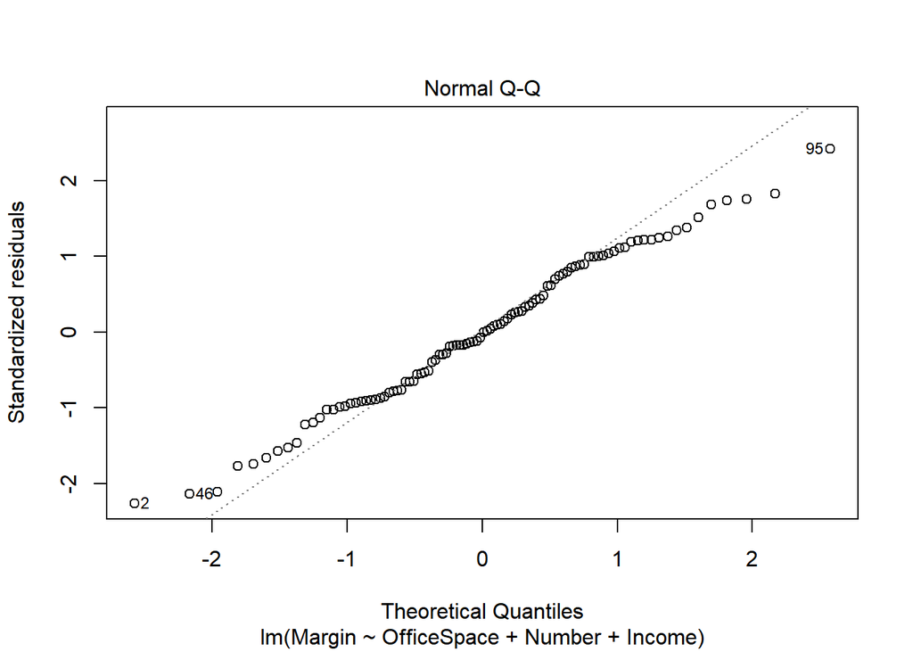

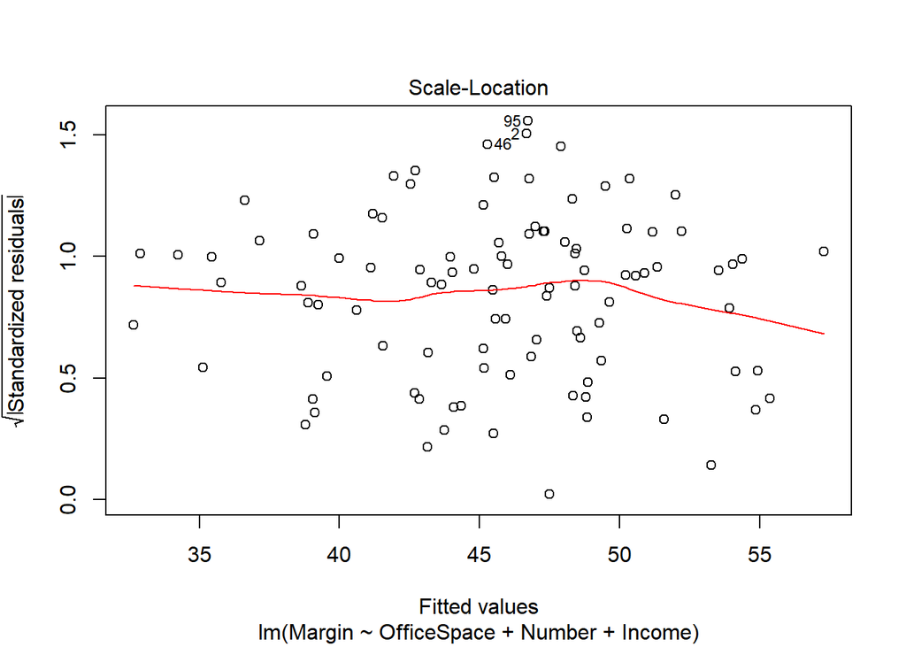

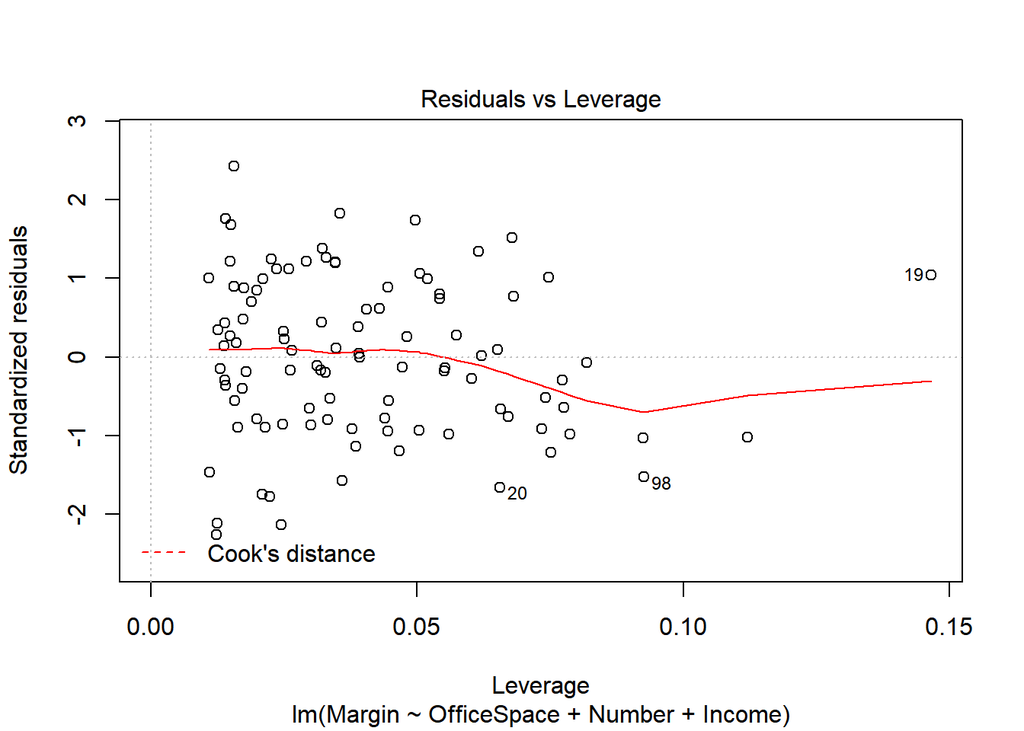

```r
plot(laQuintaModelMultiple)
```

## Conclusion and Recommendations

Discuss why you chose the model you settled on. Focus on the model fit, residuals, significance, etc. This is the most important part of the assignment. Make sure to give concrete recommendations to LaQuinta in context. You should use common business language explaining what factors are relevant without focusing solely on the statistical jargon.

### We arrived at our model, because we preferred simplicity. We used only three factors, OfficeSpace, Number, and Income to determine Margin. The components were independent of each other and each contributed value margin. Office Space we thought would be a good proxy for Demand for your hotel. Number was representative of local supply of hotels and competitition. Income was an indicator of how sensitive our customers were to prices.

There is a location of interest that has 3815 rooms within 3 miles, the closest hotel is 0.9 miles away, the amount of office space is 476,000 square feet, there is one college and one university with a total enrollment of 24,500, the median income in the area is $35,000, and the distance to the downtown core is 11.2 miles. Form a 95% prediction interval for the operating margin at this location **based on your model**. Profitable inns are defined by those with operating margins greater than 50%. Would you recommend this site?

```r
MarginPredict <- predict(laQuintaModelMultiple, newdata = data.frame(Number = 3815, OfficeSpace = 476, Income = 35))

MarginPredictConf <- predict(laQuintaModelMultiple, newdata = data.frame(Number = 3815, OfficeSpace = 476, Income = 35),interval = "predict", level = .95)

MarginPredict
```

```
##        1
## 38.66873
```

```r
MarginPredictConf
```

```
##        fit      lwr     upr
## 1 38.66873 27.03856 50.2989
```